# Assignment 1 - Donal Conlon - 21253090

### Import Packages to begin session.

```python
import numpy as np
import pandas as pd
import matplotlib as mpl
%matplotlib inline
mpl.rcParams['figure.figsize'] = (15, 10)
```

### Import house price data

```python
hp = pd.read_csv('hpdemo.csv',dtype=float)
```

# 3-D plot of the house price for average floor area

#### Create Pipeline for predicted house price based on Easting, Northing and average floor area.

```python
from sklearn.pipeline import Pipeline
from sklearn.preprocessing import StandardScaler
from sklearn.neighbors import KNeighborsRegressor as NN
from sklearn.metrics import mean_absolute_error, make_scorer
mae = make_scorer(mean_absolute_error, greater_is_better=False)
from sklearn.model_selection import GridSearchCV
```

```python
price = hp['price']/1000.0
```

```python
pipe = Pipeline([('zscores',StandardScaler()),('NNreg',NN())])

opt_pipe = GridSearchCV(
    estimator = pipe,
    scoring = mae,
    param_grid = {
        'NNreg__n_neighbors':range(1,35),
        'NNreg__weights':['uniform','distance'],
        'NNreg__p':[1,2]})

opt_pipe.fit(hp[['east','north','fl_area']],price)
```

```
GridSearchCV(estimator=Pipeline(steps=[('zscores', StandardScaler()),
                                       ('NNreg', KNeighborsRegressor())]),
             param_grid={'NNreg__n_neighbors': range(1, 35), 'NNreg__p': [1, 2],
                         'NNreg__weights': ['uniform', 'distance']},
             scoring=make_scorer(mean_absolute_error, greater_is_better=False))
```

#### Create Visualisation

```python
#Create mesh grid as canvas
east_mesh, north_mesh = np.meshgrid(np.linspace(505000,555800,100), np.linspace(158400,199900,100))
fl_mesh = np.zeros_like(east_mesh)
fl_mesh[:,:] = np.mean(hp['fl_area'])
grid_predictor_vars = np.array([east_mesh.ravel(), north_mesh.ravel(),fl_mesh.ravel()]).T
hp_pred = opt_pipe.predict(grid_predictor_vars)
hp_mesh = hp_pred.reshape(east_mesh.shape)
```

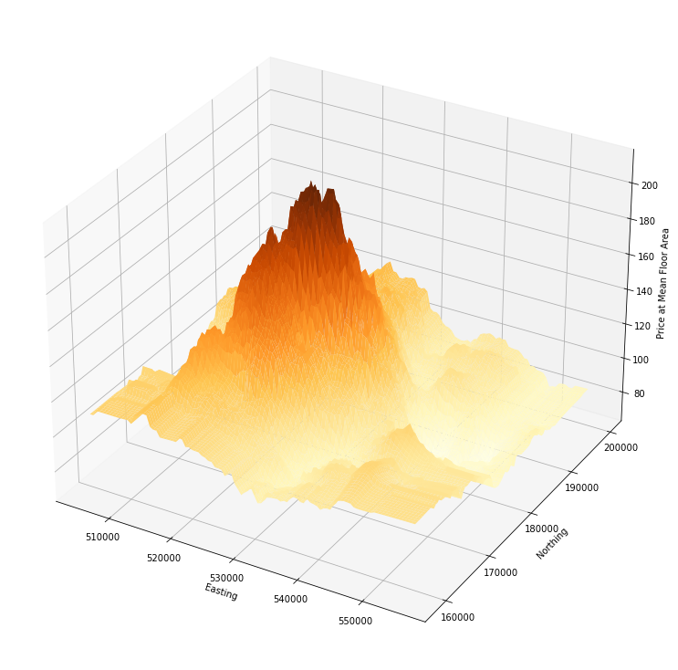

```python
import pylab as pl
from mpl_toolkits.mplot3d import Axes3D

fig = pl.figure()
ax = Axes3D(fig)
ax.plot_surface(east_mesh, north_mesh, hp_mesh, rstride=1, cstride=1, cmap='YlOrBr',lw=0.01)
ax.set_xlabel('Easting')
ax.set_ylabel('Northing')
ax.set_zlabel('Price at Mean Floor Area')
pl.show()
```

# A 3-D plot of the house price for floor areas of 75 square metres.

```python
def surf3d(pipe_model,fl_area):
    east_mesh, north_mesh = np.meshgrid(
        np.linspace(505000,555800,100),
        np.linspace(158400,199900,100))
    fl_mesh = np.zeros_like(east_mesh)
    fl_mesh[:,:] = fl_area
    grid_predictor_vars = np.array([east_mesh.ravel(),north_mesh.ravel(),fl_mesh.ravel()]).T
    hp_pred = pipe_model.predict(grid_predictor_vars)
    hp_mesh = hp_pred.reshape(east_mesh.shape)
    fig = pl.figure()
    ax = Axes3D(fig)
    ax.plot_surface(east_mesh, north_mesh, hp_mesh, rstride=1, cstride=1, cmap='YlOrBr',lw=0.01)
    ax.set_xlabel('Easting')
    ax.set_ylabel('Northing')
    ax.set_zlabel('Price')
    pl.show()
    return
```

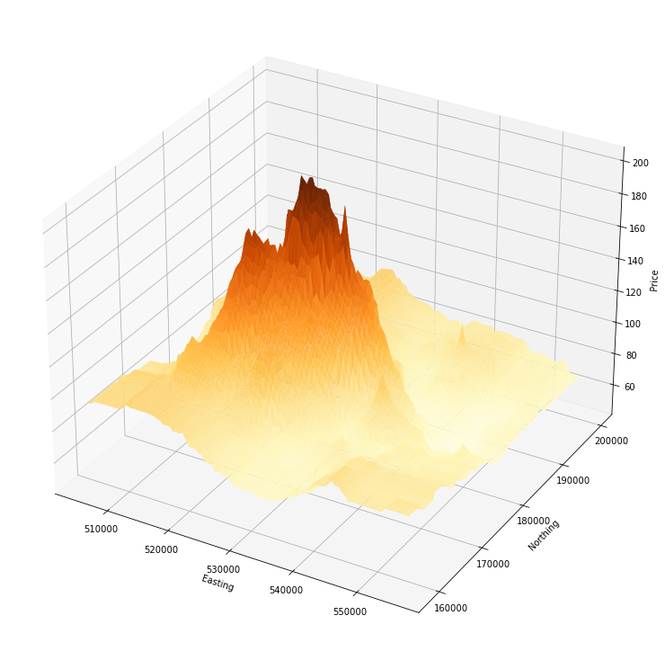

```python
surf3d(opt_pipe,75.0)
pl.savefig('figure75.pdf')
pl.close()
```

# A 3-D plot of the house price for floor areas of 125 square metres.

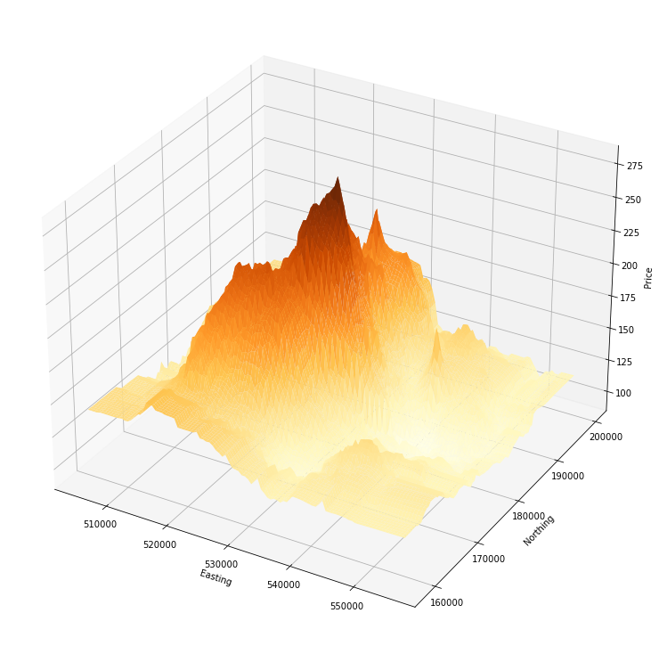

```python
surf3d(opt_pipe,125.0)
pl.savefig('figure125.pdf')
pl.close()
```

# A 3-D plot of the house price for floor areas of 250 square metres.

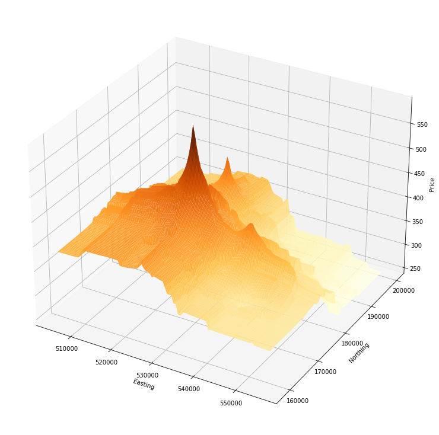

```python
surf3d(opt_pipe,250)
pl.savefig('figure125.pdf')
pl.close()
```

# Report

The following report seeks to illustrate the technique used to construct each 3-D plot of house price through Easting & Northing location, from machine learning pipeline right through to data visualization. We will also delve into what differences are exhibited across price for varying floor areas, and what these differences mean in the overall assessment of each plot, as well as touching on the subtleties and nuances that exist in K nearest neighbor predictive models.

I began by importing all necessary packages; numpy, pandas and matplotlib, as well as importing the housing dataset. I decided to use the pipeline technique, as it is the smoothest way to create the plots, and will likely serve me well in the future, thus I wanted to get to grips with it here. Several functions from the sk.learn package were employed to create and execute the pipeline. The first of which was StandardScaler, which allows us to convert variables into z-scores, ensuring a common scale is observed, whilst still retaining the same variance in their relationship. Several different machine learning algorithms were at our disposal, however, k-nearest neighbours seemed most appropriate as house prices are often intrinsically linked with location. Thus, we imported the KNeighborsRegressor function, abbreviated as NN. Both functions – StandardScaler & KNeighborsRegressor are passed through the pipeline argument as a list of tuples, we name this object pipe. Rather than trying to tune the parameters myself, I opted for a cross-validation ‘grid-search’, to optimize results. As the sklearn package doesn’t directly provide a cross-validation function, we had to create a scoring object. I chose to use the mean absolute error as the empirical scorer. Other arguments passed through the GridSearchCV function include; estimator – specifying the machine learning algorithm, and param_grid – a dictionary of tuning parameters to cycle through until the combination with the lowest MAE is found. The outcome is stored in the opt_pipe object, before further .fit and .predict methods are applied. The k nearest neighbors’ pipeline was now complete.

The next task at hand pertains to the visualization and description of results. We begin by creating a mesh grid as our canvas, covering 100 x 100 points within the specified Easting and Northing Range. A third parameter, floor area is added. Things become a bit tricky as the predict method, essential to plotting our parameter space is only accessible by ‘unravelling’ each variable into a single dimensional array. Following some necessary ‘ravelling’ and ‘re-shaping’, the data was wrangled inot a grid format, capable of carrying house price predictions. Finally, we add a function to automate the surface drawing, passing through the KNN pipeline model as well as a fixed floor area as arguments. The function is reproduced for each instance of the 3D plot.

To summarise our findings – at different levels of floor area, Easting and Northing exert varying degrees of influence on the prediction of price. That is to say, for dwellings at each end of the floor area scale, Easting and Northing play a slightly less important role in predicting price than for average sized homes.

That said, there is an underlying issue of economies of scale here. Another reason for little to no variation in prediction surface for Easting and Northing – at the premium end of the market, is that larger homes, are by nature, built in more affluent areas. We are far less likely to see an eight bedroomed Victorian mansion built in between blocks of highrise flats, correct? I would argue that the lack of spatial variation is owed to the almost exclusive ownership of larger homes by the affluent. Thus I think any assumption made vis-à-vis Easting and Northing homes playing a lesser role in house prices might be ill-fated.